# Angewandte Statistik Bachelor of Science

Deskriptive Statistik

Patric Eichelberger

patric.eichelberger@bfh.ch

Bern University of Applied Sciences

10.09.2026

## Inhalte

- Grundbegriffe
- Qualitative und quantitative Daten: Variablentypen
- Kennzahlen der Lage und Streuung
  - Mittelwert, Median, Perzentile/Quantile
  - Varianz, Standardabweichung, Interquartilsabstand, Spannweite
  - Absolute und relative Häufigkeiten
- Grafische Darstellung
  - Histogramm
  - Boxplot
  - Balkendiagramm
  - Kreuztabelle

## Modul Angewandte Statistik

**Inferenzielle (schliessende) Statistik**

- Schätzen von wahren Kennzahlen (z.B. Mittelwert) in der Population (auch Grundgesamtheit).
- Verallgemeinerung der Stichproben-Kennzahlen: Benötigt eine repräsentative Zufallsstichprobe.
- Liefert Angaben bis zu welchem Grad man den Schätzungen vertrauen kann.

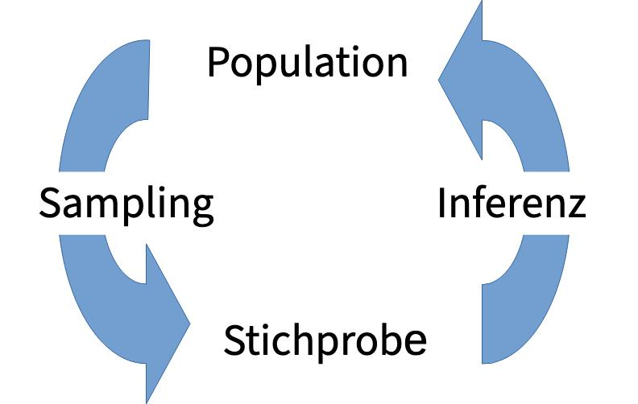

**Deskriptive (beschreibende) Statistik**

- Daten einer Stichprobe (engl. sample) zusammenfassend beschreiben. Keine Verallgemeinerung der Ergebnisse.
- Kennzahlen der Lage (z.B. Mittelwert, Median) und Streuung (z.B. Standardabweichung, Interquartilsabstand).
- Grafisch: Boxplot und Histogramm, Tabellarisch: Kreuztabellen.

## Grundbegriffe

**Beobachtungseinheit**

- Objekte, an denen Merkmale gemessen werden.
- Zeilen in Datentabelle.

**Beobachtungsmerkmal/Variable**

- Beobachtetes oder gemessenes Merkmal einer Beobachtungseinheit (z.B. Körpergrösse)
- Spalte in Datentabelle

**Merkmalsausprägungen**

- Konkrete Werte von Beobachtungsmerkmalen (z.B. Körpergrösse = 170 cm)
- Wert in Zelle in Datentabelle

| ID | Augenfarbe | Groesse | Gewicht |
| --- | --- | --- | --- |
| 1 | blau | 170 | 62 |
| 2 | gruen | 160 | 56 |
| 3 | blau | 169 | 68 |
| 4 | blau | 182 | 70 |
| 5 | gruen | 173 | 73 |

## Merkmalstypen (Skalenniveaus)

| Typ | Beschreibung | Beispiel |
| --- | --- | --- |
| qualitativ-nominal | Daten bilden **ungeordnete** Kategorien | Augenfarbe, Kanton |
| qualitativ-ordinal | Daten bilden **geordnete** Kategorien | Schmerzen (wenig, mittel, stark), Kleidergrössen |
| quantitativ-diskret | Daten werden **gezählt** | Anzahl Geschwister, Anzahl Studierende |
| quantitativ-kontinuierlich | Daten werden **gemessen** | Körpergewicht, Blutdruck |

**Art des Nullpunktes bei quantitativ-kontinuierlich**

- Rationalskaliert: 0 ist ein absoluter Wert (z.B. Alter, Gewicht). Verhältnisse bilden möglich: 100 kg sind doppelt so schwer wie 50 kg.
- Intervallskaliert: 0 ist ein willkürlicher Wert (z.B. Temperatur Celsius-Skala: 0 heisst nicht keine Wärme). Verhältnisse bilden nicht möglich: 10° C ist nicht doppelt so warm wie 5° C.

# Quantitative Merkmale

**Lagekennzahlen**

- Mittelwert
- Median
- Perzentile/Quantile

**Streuungskennzahlen**

- Varianz/Standardabweichung
- Interquartilsabstand
- Spannweite (Variationsbreite)

## Quantitative Merkmale

**Lagekennzahlen**

- Mittelwert
- Median
- Perzentile/Quantile

**Streuungskennzahlen**

- Varianz/Standardabweichung
- Interquartilsabstand
- Spannweite (Variationsbreite)

## Mittelwert

Stichprobe von $n$ Beobachtungen $x_1, x_2, ..., x_n$
$$\bar{x}=\frac{1}{n}\sum_{i=1}^{n}x_i = \frac{x_1+x_2+...+x_n}{n}$$

| ID | Groesse |
| --- | --- |
| 1 | 170 |
| 2 | 160 |
| 3 | 169 |
| 4 | 182 |
| 5 | 173 |

**Beispiel**

$x_1=170,x_2=160,x_3=169,x_4=182,x_5=173$

$$\bar{x}=\frac{170+160+169+182+173}{5} = 170.8$$

## Median

Der Median teilt die Stichprobe in zwei Hälften. 50% der Daten sind kleiner als der Median, 50% der Daten sind grösser als der Median. Der Median ist sozusagen der Wert in der Mitte.

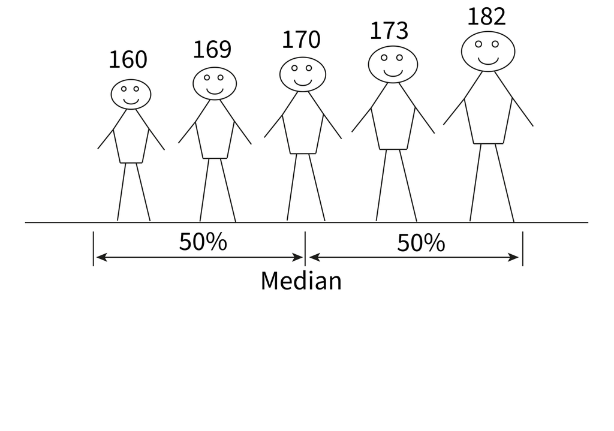

## Median: Ungerades $n$

| ID | Groesse |
| --- | --- |
| 1 | 170 |
| 2 | 160 |
| 3 | 169 |
| 4 | 182 |
| 5 | 173 |

| ID | Groesse |
| --- | --- |
| 2 | 160 |
| 3 | 169 |
| 1 | 170 |
| 5 | 173 |
| 4 | 182 |

**Beispiel**

$$\begin{align*}
\tilde{x} &= x_{(\frac{n+1}{2})} \\
&= x_{(\frac{5+1}{2})} = x_{(3)} = 170
\end{align*}$$

## Median: Gerades $n$

[figure not shown]

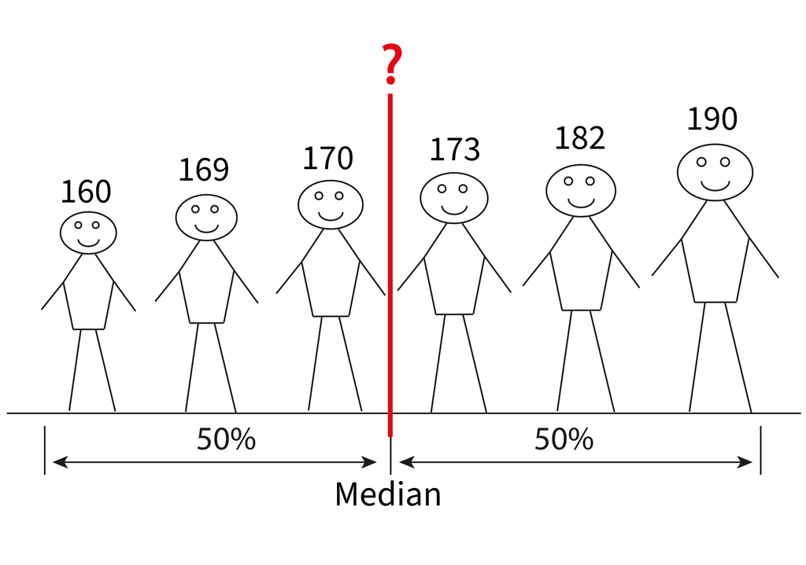

## Median: Gerades $n$ (cont.)

| ID | Groesse |
| --- | --- |
| 1 | 170 |
| 2 | 160 |
| 3 | 169 |
| 4 | 182 |
| 5 | 173 |
| 6 | 190 |

| ID | Groesse |
| --- | --- |
| 2 | 160 |
| 3 | 169 |
| 1 | 170 |
| 5 | 173 |
| 4 | 182 |
| 6 | 190 |

## Min, Max & Quantile

- Das Minimum $x_{(1)}$ und das Maximum $x_{(n)}$ beschreiben die Extremwerte.
- $Q_1$ (1. Quartil)
  - Teilt die Stichprobe im Verhältnis 1:3
  - 25% aller Werte liegen darunter, 75% darüber
- $Q_3$ (3. Quartil)
  - Teilt die Stichprobe im Verhältnis 3:1
  - 75% aller Werte liegen darunter, 25% darüber

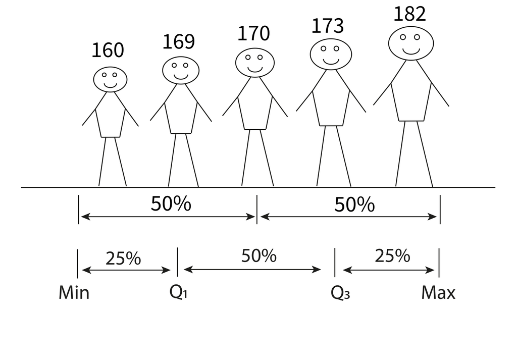

## Min, Max & Quantile

- Das $\alpha$-Quantil $x_\alpha$ oder $100\alpha$%-Perzentil teilt die Stichprobe im Verhältnis $\alpha:(1-\alpha)$
- $100\alpha$% aller Werte liegen darunter, $100(1-\alpha)$% darüber
- 1. Quartil: unteres Quartil / $x_{0.25}$ Quantil / 25. Perzentil
- 2. Quartil: Median / $x_{0.5}$ Quantil / 50. Perzentil
- 3. Quartil: oberes Quartil / $x_{0.75}$ / 75. Perzentil

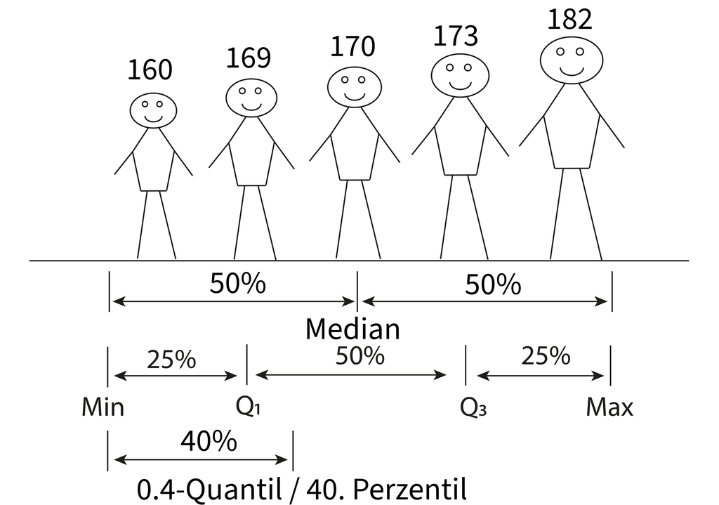

## Quantitative Merkmale

**Lagekennzahlen**

- Mittelwert
- Median
- Perzentile/Quantile

**Streuungskennzahlen**

- Varianz/Standardabweichung
- Interquartilsabstand
- Spannweite (Variationsbreite)

## Spannweite und IQR

**Spannweite/Variationsbreite**

Misst den Wertebereich:

Spannweite = Max. - Min.

**Interquartilsabstand (IQR)**

Differenz zwischen 3. und 1. Quartil:

$\mathrm{IQR} = Q_3-Q_1$

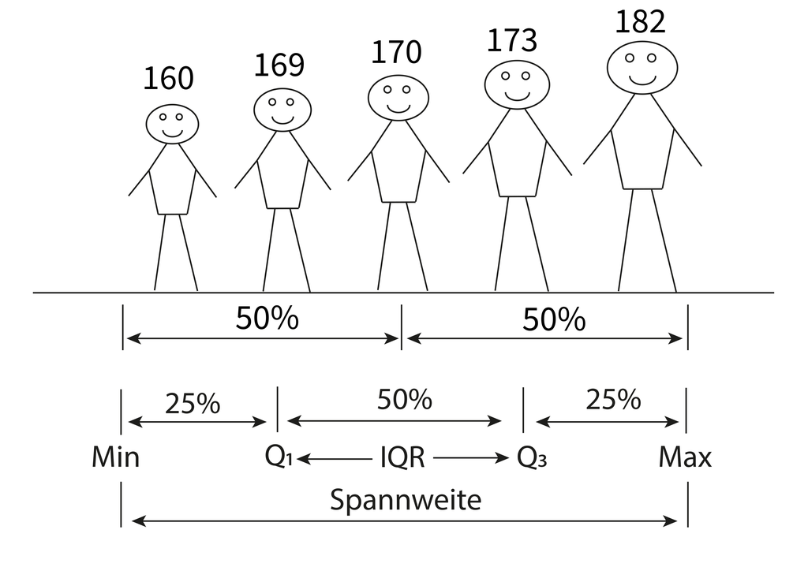

## Varianz und Standardabweichung

Varianz: Mittlere quadratische Abweichung der Daten vom Mittelwert.

$$\begin{equation*}
s^2=\frac{1}{n-1}\sum_{i=1}^{n}(x_i-\bar{x})^2=\frac{(x_1-\bar{x})^2+...+(x_n-\bar{x})^2}{n-1}
\end{equation*}$$

Standardabweichung: Quadratwurzel der Varianz.

$$s=\sqrt{s^2}$$

| ID | Groesse |
| --- | --- |
| 1 | 170 |
| 2 | 160 |
| 3 | 169 |
| 4 | 182 |
| 5 | 173 |

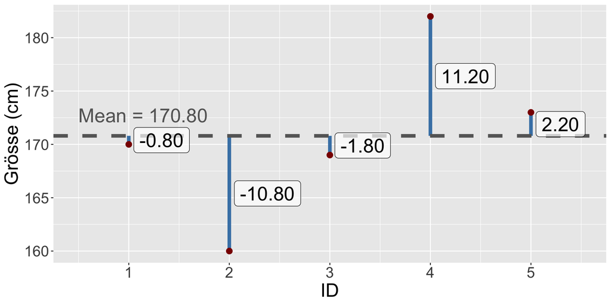

## Varianz und Standardabweichung

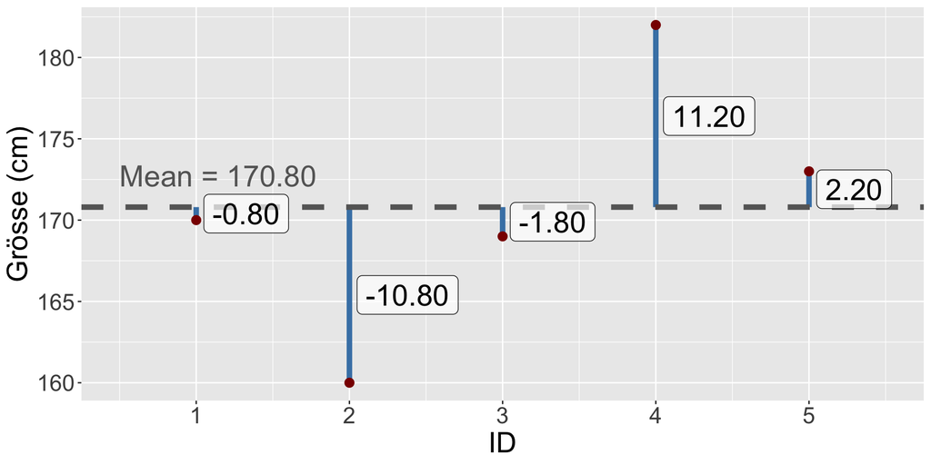

**Beispiel**

$$\begin{equation*}
s^2=\frac{1}{n-1}\sum_{i=1}^{n}(x_i-\bar{x})^2=\frac{(x_1-\bar{x})^2+...+(x_n-\bar{x})^2}{n-1}
\end{equation*}$$
$$s^2=\frac{(170-170.8)^2+(160-170.8)^2+(169-170.8)^2+(182-170.8)^2+(173-170.8)^2}{4}= 62.7$$

$$s=\sqrt{62.7}=7.9$$

## Quantitative Merkmale

**Lagekennzahlen**

- Mittelwert
- Median
- Perzentile/Quantile

**Streuungskennzahlen**

- Varianz/Standardabweichung
- Interquartilsabstand
- Spannweite (Variationsbreite)

## Histogramm

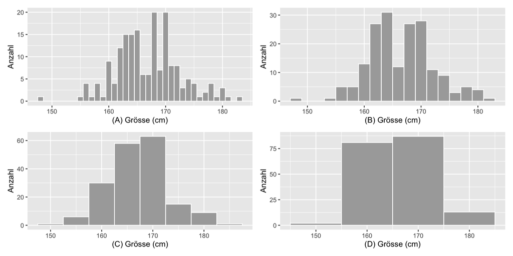

Körpergrösse von Frauen, n = 183

## Boxplot

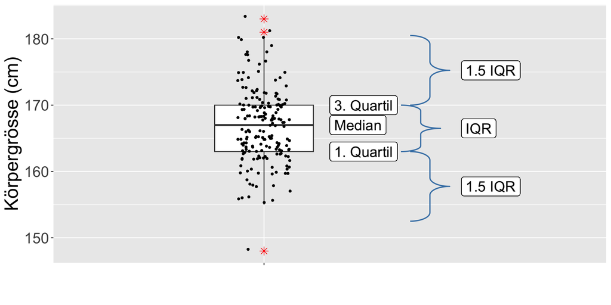

Körpergrösse von Frauen, n = 183

## Histogramm vs. Boxplot

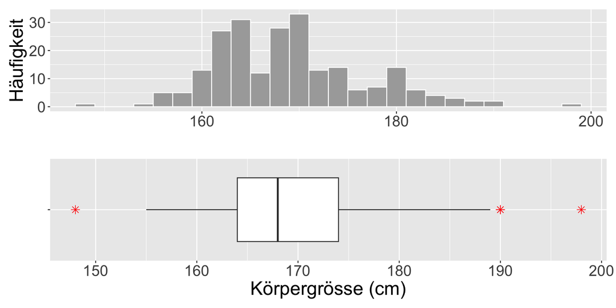

Körpergrösse, n = 228

## Robustheit

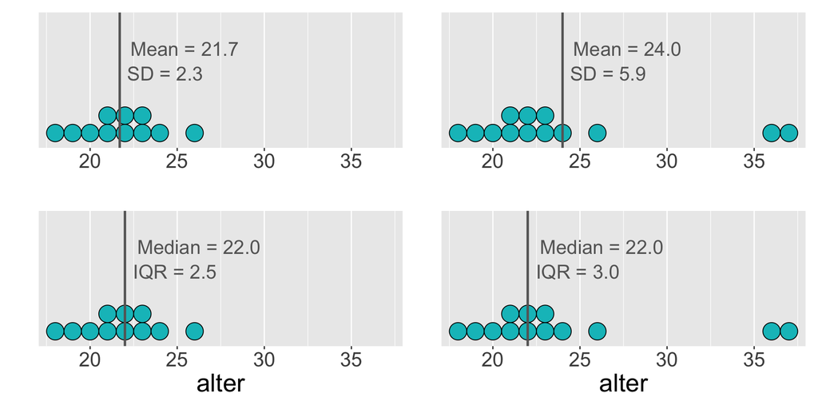

## Symmetrie und Schiefe

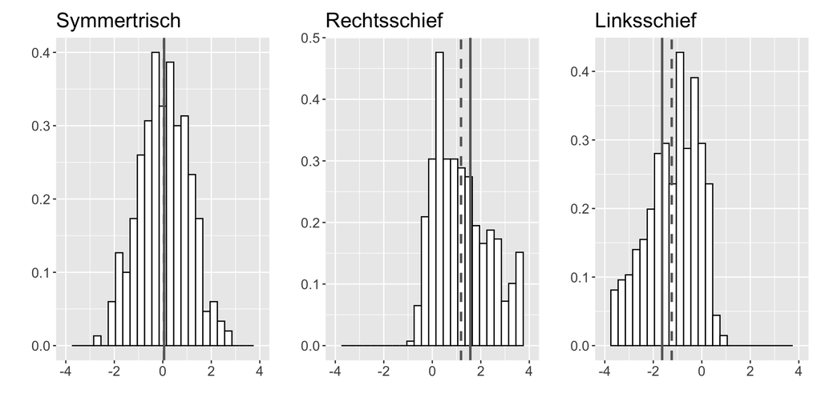

# Qualitative Merkmale

Kreuztabellen

| Kaffees | n | Prozent |
| --- | --- | --- |
| 0 | 1 | 0.7 |
| 1 | 7 | 4.7 |
| 2 | 31 | 20.7 |
| 3 | 68 | 45.3 |
| 4 | 33 | 22.0 |
| 5 | 10 | 6.7 |
| Total | 150 | 100.0 |

Balkendiagramme

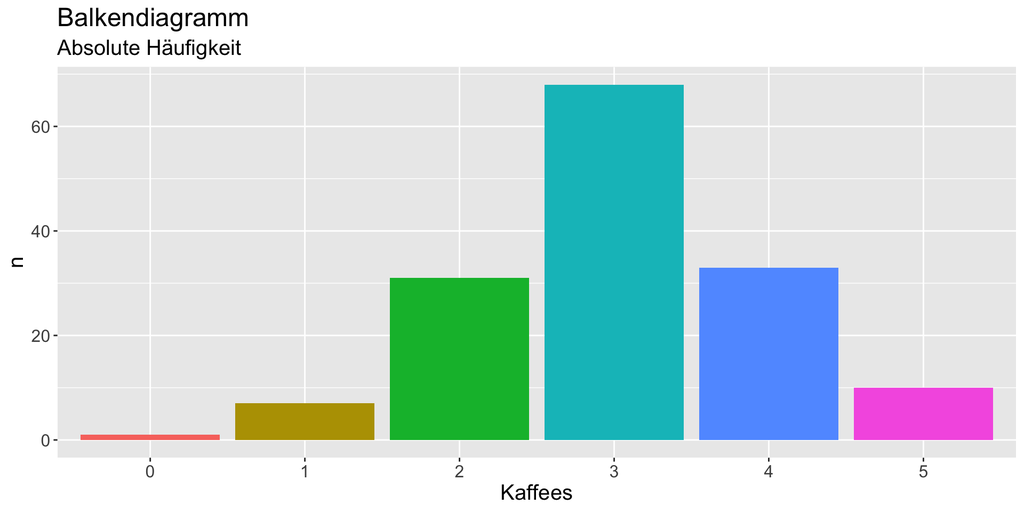

## Kreuztabellen

| ID | Kaffees |
| --- | --- |
| 1 | 3 |
| 2 | 2 |
| 3 | 3 |
| 4 | 4 |
| 5 | 3 |
| 6 | 2 |
| 7 | 3 |

| Kaffees | n | Prozent |
| --- | --- | --- |
| 0 | 1 | 0.7 |
| 1 | 7 | 4.7 |
| 2 | 31 | 20.7 |
| 3 | 68 | 45.3 |
| 4 | 33 | 22.0 |
| 5 | 10 | 6.7 |
| Total | 150 | 100.0 |

## Balkendiagramm

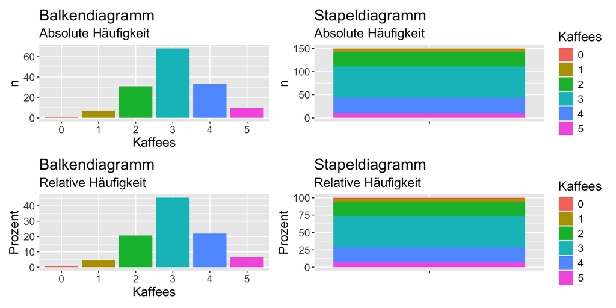

## Tortendiagramm

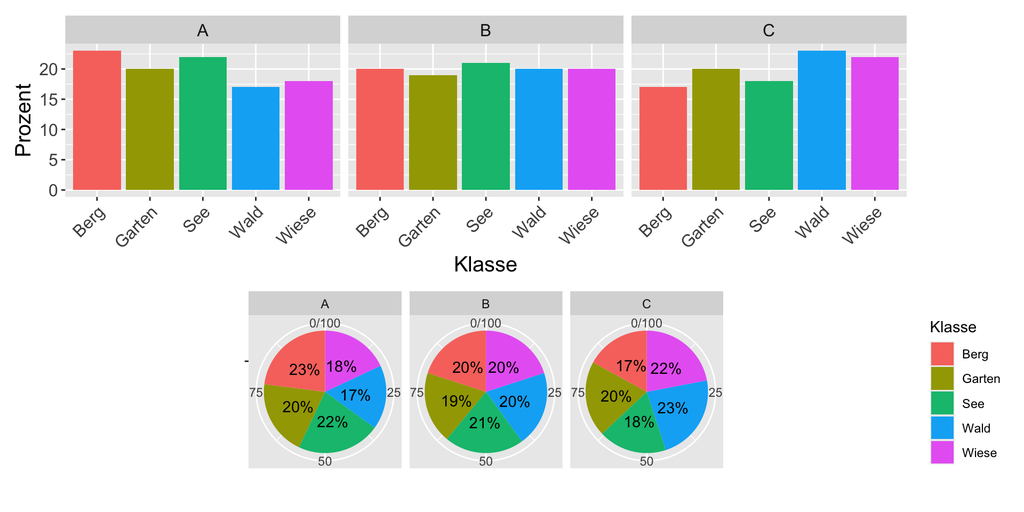

## Zusammenfassung

**Qualitative Variablen**

- Häufigkeiten (absolut, relativ)
- Balkendiagramme
- Kreuztabellen

**Quantitative Variablen**

- Lagekennzahlen
  - Mittelwert, Median
  - Perzentile
- Streuungskennzahlen
  - Standardabweichung, Interquartilsabstand
- Histogramm
- Boxplot

[figure not shown]